# Strategic Targeting of OncomiRs in Brain Tumor Therapy: A Gene Expression Analysis Approach

Mersad Abbasi

20-03-2023

## Required Packages

```r
if (!requireNamespace("devtools", quietly = TRUE))
install.packages("devtools")
if (!requireNamespace("ComplexHeatmap", quietly = TRUE))
install.packages("ComplexHeatmap")
if (!requireNamespace("circlize", quietly = TRUE))
install.packages("magick")
if (!requireNamespace("magick", quietly = TRUE))
install.packages("magick")
if (!requireNamespace("gprofiler2", quietly = TRUE))
install.packages("gprofiler2")
```

```r
## Load Required Packages
library(ComplexHeatmap)
library(circlize)
library(knitr)
library(limma)
library(edgeR)
library(ggplot2)
library(magick)
library(gprofiler2)
```

# INTRODUCTION

### Article Title:

Anti-seed PNAs targeting multiple oncomiRs for brain tumor therapy[@wang2023anti],

### Conclusion:

We established that BNPs loaded with anti-seed sγPNAs targeting multiple oncomiRs are a promising approach to improve the treatment of GBM, with a potential to personalize treatment based on tumor-specific oncomiRs [@wang2023anti].

### Dataset:

Our data set was obtained from GEO with the accession id : GSE217366. It was obtained from the article “Anti-seed PNAs targeting multiple oncomiRs for brain tumor therapy” [@wang2023anti]

### Summary of previous analysis

Previously we cleaned, normalized and mapped our dataset to HUGO symbols. The results of these analysis are summarized as follows : Cleaning: (we got rid of gene duplications and defined new groups for our samples) 21344 of the initial 35741 samples remained after removing gene duplications

```
                    Normalization: (We normalized our data by TMM) No outliers were removed after normalization

                    Mapping: (we mapped our samples gene_id that contained the ensembl id to HUGO symbol), A total of 42 genes were not mapped to HUGO symbol. The list of these genes with their expression data were displayed at the end of Assignment 1
```

# IMPORT DATA

```r
# load the data
ExpDataset <- read.csv(file=file.path(getwd(),
                "dataset.csv"),
                                    header = TRUE,sep = ",",
                                    stringsAsFactors = FALSE,
                                    check.names=FALSE, row.names = NULL)
# Only include unique hgnc_symbols
ExpDataset <-ExpDataset[match(
  unique(ExpDataset$hgnc_symbol),
  ExpDataset$hgnc_symbol), ]
kable(ExpDataset[1:5,], caption = "Loaded dataset", type="html")
```

Loaded dataset

| ensembl_gene_id | hgnc_symbol | Control-1 | Control-2 | Control-3 | PNA-10b-1 | PNA-10b-2 | PNA-10b-3 | PNA-21-1 | PNA-21-2 | PNA-21-3 | PNA-10b+21-1 | PNA-10b+21-2 | PNA-10b+21-3 |
| --- | --- | --- | --- | --- | --- | --- | --- | --- | --- | --- | --- | --- | --- |
| ENSG00000000003 | TSPAN6 | 40.472114 | 38.06137 | 42.56324 | 33.51724 | 33.03441 | 31.99784 | 28.846998 | 29.41465 | 33.588327 | 30.544296 | 30.831368 | 31.39881 |
| ENSG00000000419 | DPM1 | 94.793490 | 97.45840 | 90.96372 | 98.73409 | 99.22143 | 89.79433 | 96.234994 | 90.90559 | 96.592845 | 88.481039 | 101.454249 | 91.55894 |
| ENSG00000000457 | SCYL3 | 9.613808 | 11.34749 | 12.56629 | 10.61500 | 10.63720 | 12.02267 | 9.694001 | 10.91959 | 9.030824 | 9.914002 | 8.889594 | 9.79643 |
| ENSG00000000460 | C1orf112 | 12.706361 | 14.89358 | 11.18805 | 17.37662 | 16.84223 | 15.34143 | 16.744184 | 16.10640 | 16.794163 | 17.879588 | 16.156483 | 16.26459 |
| ENSG00000000971 | CFH | 40.875491 | 38.00227 | 45.72508 | 32.64477 | 26.23842 | 29.11741 | 24.969397 | 25.31980 | 27.356530 | 24.297902 | 28.644246 | 28.57292 |

```r
# Get rid of duplicated Ensembel_gene_ids
ExpDataset <- ExpDataset[!duplicated(ExpDataset$ensembl_gene_id), ]
```

# DIFFERENTIAL EXPRESSION ANALYSIS

For designing our model, we will be using the EdgeR package. Since we are using an experiment where the control and the treatment were both performed on U87 cells, we will use the QuasiLikelihood model in edgeR package

## Define Groups

There are 2 groups in our study : Condition and Replicate. The last character in our sample names indicate the replicate number.

```r
# Split our sample names in 2 by splitting on the last character.
SamplesInfo <- data.frame(lapply(colnames(ExpDataset)[3:14],
                                  FUN=function(x){unlist(strsplit(x, "(?<=.)(?=[^.]$)", perl=TRUE))[c(1,2)]}))

# Name the two new groups as Condition and Replicate
colnames(SamplesInfo) <- colnames(ExpDataset)[3:14]
rownames(SamplesInfo) <- c("condition", "replicate")

# Transform our data set into data frame
SamplesInfo <- data.frame(t(SamplesInfo))

# Visualize the two new groups and assignmed sample names
kable(SamplesInfo, type="html", caption = "Table 1. Defined groups for our dataset")
```

Table 1. Defined groups for our dataset

|  | condition | replicate |
| --- | --- | --- |
| Control-1 | Control- | 1 |
| Control-2 | Control- | 2 |
| Control-3 | Control- | 3 |
| PNA-10b-1 | PNA-10b- | 1 |
| PNA-10b-2 | PNA-10b- | 2 |
| PNA-10b-3 | PNA-10b- | 3 |
| PNA-21-1 | PNA-21- | 1 |
| PNA-21-2 | PNA-21- | 2 |
| PNA-21-3 | PNA-21- | 3 |
| PNA-10b+21-1 | PNA-10b+21- | 1 |
| PNA-10b+21-2 | PNA-10b+21- | 2 |
| PNA-10b+21-3 | PNA-10b+21- | 3 |

## Design Matrix

Based on the MDS plot in assignment 1, we concluded that condition of the samples (control or PNA10b+21) was the major factor contributing to the results. Considering the fact that our experiment is performed on cell line U87, this conclusion is logical.

```r
# Design our model matrix
condition <- factor(c(rep("control", 3), rep("PNA10b-21", 3)))
design_matrix <- model.matrix(~1 + condition)
colnames(design_matrix) <- levels(condition)
```

### Define edgeR DEGlist

For further analysis with edgeR package, we first need to create the DEGlist object. It should be noted that we only are going to compare only two conditions : Control (with 3 replicates) and PNA10b+21 (with 3 replicates). This is because the main hypothesis of the paper was that combined use of PNA10b and PNA21 will yield signifcant results.

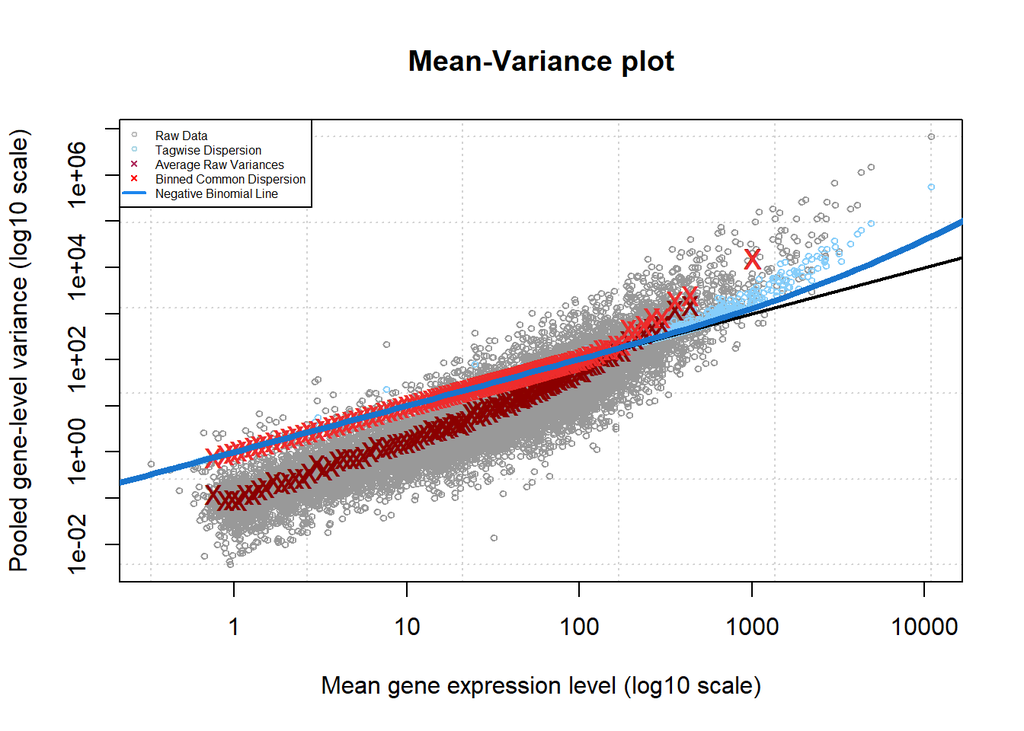

Figure 1. MeanVariance plot for our expression dataset.We can see that our data follow a negative binomial distribution and thus we can contiue with our analysis

```r
d <- DGEList(counts=ExpDataset[,c(3:5,12:14)], genes =ExpDataset[,1:2])
# Get the normalized data
d = calcNormFactors(d)
# Estimate dispersion
d <- estimateDisp(d, design_matrix)

# check to see if our data follows a non binomial distribution
plotMeanVar(d,
            show.raw.vars = TRUE,
            show.tagwise.vars = TRUE,
            NBline = TRUE,
            show.ave.raw.vars = TRUE,
            show.binned.common.disp.vars = TRUE,
            main = "Mean-Variance plot")
legend("topleft",
       legend=c("Raw Data", "Tagwise Dispersion", "Average Raw Variances",
                "Binned Common Dispersion", "Negative Binomial Line"),
       col = c("grey", "lightblue", "maroon", "red", "dodgerblue2"),
       pch=c(1,1,4,4,NA),
       lty=c(0,0,0,0,1),
       lwd=c(1,1,1,1,2),
       cex=0.5)
```

## Fit The Model

As described earlier we fit our data to the QuasiLikelihood model in edgeR package that is specifically designed for RNAseq data

```r
fit <- glmQLFit(d, design_matrix)
```

## Perform differential expression analysis

```r
qlf <- glmQLFTest(fit)
# View the result
res <- topTags(qlf, n=nrow(d), row.names(FALSE))
kable(res[1:10,1:7], digits = 80, caption = "Table 2. DEG analysis using glmQLFTest. The first 10 rows are shown")
```

Table 2. DEG analysis using glmQLFTest. The first 10 rows are shown

|  | ensembl_gene_id | hgnc_symbol | logFC | logCPM | F | PValue | FWER |
| --- | --- | --- | --- | --- | --- | --- | --- |
| 6402 | ENSG00000146674 | IGFBP3 | -1.2796902 | 8.787813 | 685.2399 | 2.091859e-15 | 2.798908e-11 |
| 9079 | ENSG00000171992 | SYNPO | -1.2733815 | 8.443982 | 340.9797 | 7.342249e-13 | 9.823195e-09 |
| 4415 | ENSG00000128510 | CPA4 | -1.0139930 | 7.779733 | 309.3691 | 1.641481e-12 | 2.195973e-08 |
| 5305 | ENSG00000136696 | IL36B | 1.0627444 | 8.041557 | 297.0007 | 2.297579e-12 | 3.073471e-08 |
| 1343 | ENSG00000088340 | FER1L4 | -1.3662388 | 7.976654 | 279.2445 | 3.813499e-12 | 5.100937e-08 |
| 9989 | ENSG00000181458 | TMEM45A | -1.2909102 | 6.081006 | 273.8267 | 4.478210e-12 | 5.989606e-08 |
| 2519 | ENSG00000107159 | CA9 | -1.1179297 | 7.652923 | 254.5411 | 8.138314e-12 | 1.088418e-07 |
| 3150 | ENSG00000114023 | FAM162A | -0.9510098 | 6.927759 | 239.3891 | 1.341714e-11 | 1.794275e-07 |
| 4597 | ENSG00000130635 | COL5A1 | -1.1156863 | 9.369598 | 228.3801 | 1.966273e-11 | 2.629301e-07 |
| 7006 | ENSG00000154721 | JAM2 | -0.9598497 | 6.555617 | 208.8045 | 4.056292e-11 | 5.423668e-07 |

[output not shown]

[output not shown]

[output not shown]

```r
# Get all of the results sorted by P-value
qlf_output_hits <- topTags(qlf,sort.by = "PValue",
n = nrow(ExpDataset))




# Extract the number of samples that passed the p-value = 0.05 threshold
length(which(qlf_output_hits$table$PValue < 0.01))
```

```
## [1] 952
```

```r
# Extract the number of samples that passed the BH correction
length(which(qlf_output_hits$table$FDR < 0.01))
```

```
## [1] 439
```

Interestingly, the number of genes that passed the correction is 439 and the number of genes that were significant without the correction is 952.

# VISUALIZATION

Here we will visualize our DE analysis using volcano plot and heatmap

## Volcano plot

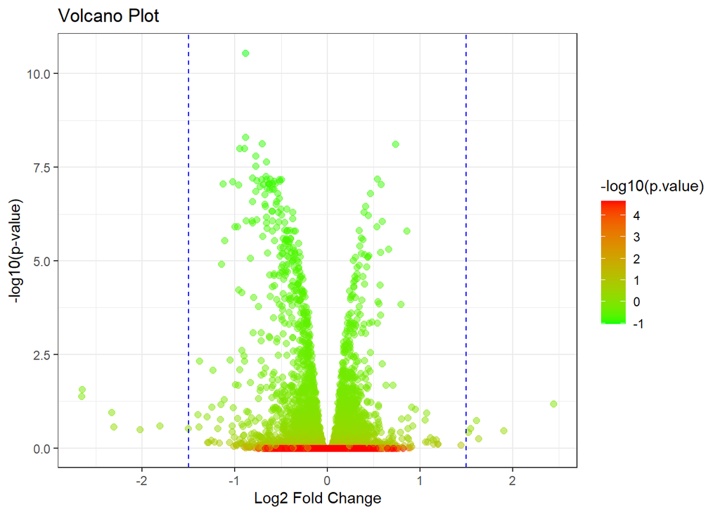

Figure 2. Volcano plot of our data after Quasilikelihood analysis. The vertical lines seperates genes which have abs Log2FC > 1.5

```r
# Extract p-values as a vector

p.value <- p.adjust(qlf$table$PValue, method = "BH")


# Extract LogFC for significant genes
logFC <- qlf$coefficients[, 2]

# Combining logFC and p.value into a data frame
df <- data.frame(logFC=logFC, p.value=-log10(p.value))

# Create volcano plot using ggplot
ggplot(df, aes(x=logFC, y=p.value, color=-log10(p.value))) +
  geom_point(size=2, alpha=0.5) +
  scale_color_gradient(low="green", high="red") +
  labs(x="Log2 Fold Change", y="-log10(p-value)", title="Volcano Plot") +
  theme_bw() + geom_vline(xintercept = c(-1.5,1.5), linetype="dashed", color="blue")
```

```r
  geom_hline(yintercept = -log10(0.01), linetype="dashed", color="blue")
```

```
## mapping: yintercept = ~yintercept
## geom_hline: na.rm = FALSE
## stat_identity: na.rm = FALSE
## position_identity
```

## Heatmap

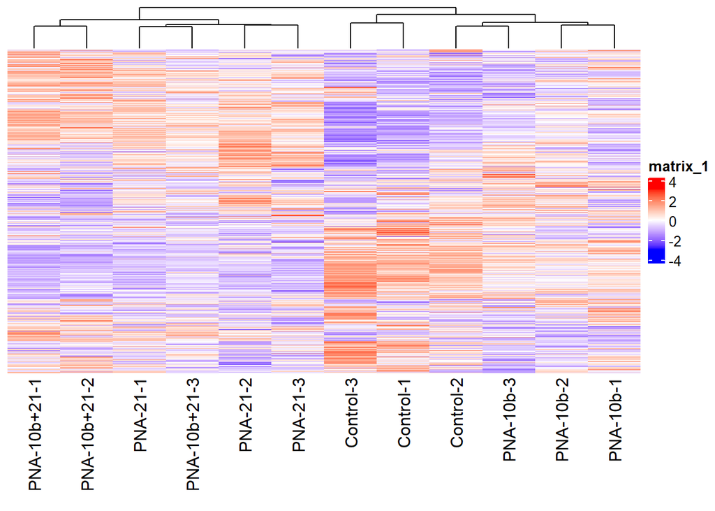

```r
# Create a heatmap matrix
heatmap_matrix <- ExpDataset[,
3:ncol(ExpDataset)]
rownames(heatmap_matrix) <- ExpDataset$ensembl_gene_id
colnames(heatmap_matrix) <- colnames(ExpDataset[,
3:ncol(ExpDataset)])

# Row-normalization
heatmap_matrix <- t(scale(t(heatmap_matrix)))

# Create heatmap

if(min(heatmap_matrix) == 0){
heatmap_col = colorRamp2(c( 0, max(heatmap_matrix)),
c( "white", "red"))
} else {
heatmap_col = colorRamp2(c(min(heatmap_matrix), 0,
max(heatmap_matrix)), c("blue", "white", "red"))
}
current_heatmap <- Heatmap(as.matrix(heatmap_matrix),
show_row_dend = FALSE,show_column_dend = TRUE,
col=heatmap_col,show_column_names = TRUE,
show_row_names = FALSE,show_heatmap_legend = TRUE, use_raster=FALSE)
current_heatmap
```

# THRESHOLDED ORA

## Find upregulated and downregulated genes

```r
# Number of genes that were upregulated
length(which(qlf_output_hits$table$PValue < 0.01
& qlf_output_hits$table$logFC > 0))
```

```
## [1] 361
```

```r
# Number of genes that were downregulated
length(which(qlf_output_hits$table$PValue < 0.05
& qlf_output_hits$table$logFC < 0))
```

```
## [1] 890
```

```r
# Merge gene names with the top hits
qlf_output_hits_withgn <- merge(ExpDataset[,1:2],qlf_output_hits, by.x=1, by.y = 1)

# Define upregulated genes and downregulated genes
upregulated_genes <- qlf_output_hits_withgn$hgnc_symbol.x[
which(qlf_output_hits_withgn$PValue < 0.01
& qlf_output_hits_withgn$logFC > 0)]
downregulated_genes <- qlf_output_hits_withgn$hgnc_symbol.x[
which(qlf_output_hits_withgn$PValue < 0.01
& qlf_output_hits_withgn$logFC < 0)]

# Export Downregulated and Upregulated genes for future analysis
write.table(x=upregulated_genes,
            file=file.path("upregulated_genes.txt"),sep = "\t",
            row.names = FALSE,col.names = FALSE,quote = FALSE)
write.table(x=downregulated_genes,
            file=file.path("downregulated_genes.txt"),sep = "\t",
            row.names = FALSE,col.names = FALSE,quote = FALSE)
```

## Find associated pathways

I used gprofiler2 package for thresholded ORA

### UP-regulated genes

```r
# Find pathways associated with the upregulated genes using gprofiler2
UPpathways <- gost(upregulated_genes,
                       organism = "hsapiens",
                       sources = c("GO:BP", "REAC", "WP"),
                       significant = TRUE,
                       user_threshold = 0.01,
                       exclude_iea = TRUE,
                       correction_method = "fdr")
# Limit term size
UPpathways <- data.frame(
  term_name = UPpathways$result$term_name[UPpathways$result$term_size < 200 &
                                               UPpathways$result$term_size > 1],
  term_id = UPpathways$result$term_id[UPpathways$result$term_size < 200 &
                                           UPpathways$result$term_size > 1],
  source = UPpathways$result$source[UPpathways$result$term_size < 200 &
                                         UPpathways$result$term_size > 1])
# Number of total genesets
length(UPpathways$term_name)
```

```
## [1] 394
```

```r
# Print the pathways
kable(head(UPpathways, 5), format = "html", caption = "Table 3. Top 5 pathways associated with our upregulated genes")
```

Table 3. Top 5 pathways associated with our upregulated genes

| term_name | term_id | source |
| --- | --- | --- |
| mitotic sister chromatid segregation | GO:0000070 | GO:BP |
| spindle organization | GO:0007051 | GO:BP |
| regulation of chromosome segregation | GO:0051983 | GO:BP |
| microtubule cytoskeleton organization involved in mitosis | GO:1902850 | GO:BP |
| mitotic spindle organization | GO:0007052 | GO:BP |

Upregulated pathways are shown above, which include pathways associated with cell division and cell cycle.

## Down-Regulated genes

```r
# Find pathways associated with the downregulated genes using gprofiler2
DOWNpathways <- gost(downregulated_genes,
                       organism = "hsapiens",
                       sources = c("GO:BP", "REAC", "WP"),
                       significant = TRUE,
                       user_threshold = 0.01,
                       exclude_iea = TRUE,
                       correction_method = "fdr")
# Limit term size
DOWNpathways <- data.frame(
  term_name = DOWNpathways$result$term_name[DOWNpathways$result$term_size < 200 &
                                               DOWNpathways$result$term_size > 1],
  term_id = DOWNpathways$result$term_id[DOWNpathways$result$term_size < 200 &
                                           DOWNpathways$result$term_size > 1],
  source = DOWNpathways$result$source[DOWNpathways$result$term_size < 200 &
                                         DOWNpathways$result$term_size > 1])
# Number of total genesets
length(DOWNpathways$term_name)
```

```
## [1] 249
```

```r
# Print the pathways
kable(head(DOWNpathways, 5), format = "html", caption = "Table 4. Top 5 pathways associated with our downregulated genes")
```

Table 4. Top 5 pathways associated with our downregulated genes

| term_name | term_id | source |
| --- | --- | --- |
| response to hypoxia | GO:0001666 | GO:BP |
| response to decreased oxygen levels | GO:0036293 | GO:BP |
| response to oxygen levels | GO:0070482 | GO:BP |
| integrin-mediated signaling pathway | GO:0007229 | GO:BP |
| collagen fibril organization | GO:0030199 | GO:BP |

Downregulted pathways are shown above, which include pathways associated with response to hypoxia